# Chapter 2 - Data Preparation

# 4 Data Cleaning

By displaying our data’s info() we can see that there are three columns which contain missing values. These are feel_temperature, weather_code and season. Some machine learning models cannot take missing data as an input and therefore we need to handle it.

There are many different options for filling in missing data, each of which has benefits and restrictions that may affect our produced model. It is important that domain knowledge is used when deciding what method to employ. How the data was produced, and what effects may have caused missing data are important to know, as well as the future modelling planned with the data. There are a range of types of missing value types. The study of missing values and how to treat them is an extremely important part of statistics, but beyond the scope of this course. For more information on the different types and treatments see this wikipedia article.

To demonstrate some common methods for filling in data, each column will be filled using a different method. These methods are merely three options, the possible ways are limitless and range from simple models, such as dropping rows or columns with missing data, to building neural networks that predict the missing value. The pandas class conveniently contains functions which allow us to easily implement some methods for data cleaning.

## 4.1 Converting Types

Sometime our pandas loading of the data will convert data types on our behalf, but this could be into the wrong format. For example, our date data is currently an “object”, whereas we want it to be in a time based format.

```python
# We can cast one type to another with astype()
original_data['date'] = original_data['date'].astype('datetime64[ns]')
```

We could also convert our count count data to a float type if we wanted to have all out numerics as floats.

```python
original_data['count'].astype('float')
```

```
0       9234.0
1      20372.0
2      20613.0
3      21064.0
4      15601.0
        ...
725    11566.0
726    11424.0
727     6421.0
728    11823.0
729    19436.0
Name: count, Length: 730, dtype: float64
```

## 4.2 Dropping Rows

If we have large amounts of data then we don’t necessarily need every single record. Because of this, we can remove the rows that contain missing data. It is important that there is no significant information contained in these rows with missing data.

For example, if all the missing data was originally one category of target data, by removing these records our overall data will be skewed away from that category. However, if there isn’t a relationship between missing data of one variable and other columns then this is an easy method to choose and understand.

We are going to drop rows that contain missing values in the weather_code column.

This can be done to a data frame using the dropna() function.

When using a pandas data frame it is crucial that we reset our indexes after we drop rows. This is done in order to prevent mis-matched indexes when converting between different data types such as numpy arrays.

```python
# Dropping rows column that contains missing values in a certain column.
clean_data = original_data.dropna(subset=['weather_code'])

# We are going to remove row indexes without values and reset all values so they are sequential.
clean_data = clean_data.reset_index(drop=True)
```

## 4.3 Replacing with an Average

Replacing a missing value with an average value of a variable is often a good approximation for the data. This can be useful because an average will not significantly impact the distribution if there are small amounts of missing data. Which average is used will depend on the data type of the variable in question.

**Mean** - Numerical data - If your variable is distributed in a symetric manner.

**Median** - Numerical data - If your variable is not distributed in a symetric manner.

**Mode** - Categorical data - replaces missing data with the most common category in the data.

We need to be careful not to over use this method as replacing large amounts of our data with the average will change the distribution of our data.

We are going to use the median average to fill in the missing data in the feel_temperature variable.

First, calculate the median of the data set. Secondly replace the missing values in the columns using fillna()

```python
# Calculate the median of feel temperature.
feel_temperature_median = clean_data['feel_temperature'].median()

# Fill in the missing values with the median value.
clean_data['feel_temperature'] = clean_data['feel_temperature'].fillna(feel_temperature_median)

# Calling the series displays it's values as an output.
clean_data['feel_temperature']
```

```
0      0.00
1      7.25
2      5.75
3      5.50
4      6.75
       ...
674    1.00
675    5.00
676    4.75
677    0.50
678    0.50
Name: feel_temperature, Length: 679, dtype: float64
```

*fillna()* :

We can also use other methods in the **fillna()** function which allows us to remove all types of missing data, with a vaiety of options for how. You can find more information about the different choices in the **fillna()** documentation online.

## 4.4 Interpolation - Inferring Missing Values

Using the other variables and values in the data we can utilise different algorithms to infer what the missing data value could be. These methods include but are not limited to:

**‘pad’** - fills in the missing values with the previous value going down the column. (Useful for when the order of the data matters i.e. time series data)

**‘linear’** - fills in the missing values using a linear function between the point before and the point after the missing value.

**‘nearest’** - fills in the missing values with the value of the nearest other point based on unique ID.

Below we are going to use the ‘pad’ method on the missing value column season.

**Warning**

Depending on the method, interpolation may not fill in all missing values, be sure to check it has worked before you continue using your data. If necessary you can always use multiple methods to fill in your missing data.

```python
# The missing data is filled with the previous values going down the row.
clean_data['season'] = clean_data['season'].interpolate(method='pad')

clean_data.isna().sum()
```

```
date                0
real_temperature    0
feel_temperature    0
humidity            0
wind_speed          0
weather_code        0
is_holiday          0
is_weekend          0
season              0
count               0
dtype: int64
```

**Warning**

Please ensure you use the designated names for all data and variables in the exercises in this course. This will allow you to copy and paste the exercise answers should you miss one of the exercises as each exercise depends on the previous.

**Exercise 1:**

Clean all the data from the data frame **original_data** using methods of your choice. Call the new cleaned data frame **clean_data**. Use the **.isna().sum()** methods to check your method has filled all missing data.

```python
original_data.info()
```

```
<class 'pandas.core.frame.DataFrame'>
RangeIndex: 730 entries, 0 to 729
Data columns (total 10 columns):
 #   Column            Non-Null Count  Dtype
---  ------            --------------  -----
 0   date              730 non-null    datetime64[ns]
 1   real_temperature  730 non-null    float64
 2   feel_temperature  657 non-null    float64
 3   humidity          730 non-null    float64
 4   wind_speed        730 non-null    float64
 5   weather_code      679 non-null    object
 6   is_holiday        730 non-null    bool
 7   is_weekend        730 non-null    bool
 8   season            694 non-null    object
 9   count             730 non-null    int64
dtypes: bool(2), datetime64[ns](1), float64(4), int64(1), object(2)
memory usage: 47.2+ KB
```

```python
# Write your code here

# The missingness of weather code is a hard one to relate to other columns in the data, as such I would deem is MCAR
# for now and drop the missing rows.

clean_data = original_data.dropna(subset = ['weather_code'])

clean_data.info()

# Reset index #

clean_data.reset_index(drop = True)
```

```
<class 'pandas.core.frame.DataFrame'>
Int64Index: 679 entries, 0 to 729
Data columns (total 10 columns):
 #   Column            Non-Null Count  Dtype
---  ------            --------------  -----
 0   date              679 non-null    datetime64[ns]
 1   real_temperature  679 non-null    float64
 2   feel_temperature  613 non-null    float64
 3   humidity          679 non-null    float64
 4   wind_speed        679 non-null    float64
 5   weather_code      679 non-null    object
 6   is_holiday        679 non-null    bool
 7   is_weekend        679 non-null    bool
 8   season            646 non-null    object
 9   count             679 non-null    int64
dtypes: bool(2), datetime64[ns](1), float64(4), int64(1), object(2)
memory usage: 49.1+ KB
```

|  | date | real_temperature | feel_temperature | humidity | wind_speed | weather_code | is_holiday | is_weekend | season | count |
| --- | --- | --- | --- | --- | --- | --- | --- | --- | --- | --- |
| 0 | 2015-04-01 | 2.75 | 0.00 | 93.00 | 7.500000 | broken_clouds | False | True | winter | 9234 |
| 1 | 2015-05-01 | 9.00 | 7.25 | 81.50 | 8.854167 | broken_clouds | False | False | winter | 20372 |
| 2 | 2015-06-01 | 8.00 | 5.75 | 79.75 | 16.000000 | clear | False | False | winter | 20613 |
| 3 | 2015-07-01 | 9.00 | 5.50 | 81.00 | 19.760870 | scattered_clouds | False | False | winter | 21064 |
| 4 | 2015-08-01 | 9.00 | 6.75 | 79.50 | 20.479167 | rain | False | False | winter | 15601 |
| ... | ... | ... | ... | ... | ... | ... | ... | ... | ... | ... |
| 674 | 2016-12-30 | 4.00 | 1.00 | 100.00 | 9.000000 | cloudy | False | False | winter | 11566 |
| 675 | 2016-12-31 | 7.50 | 5.00 | 90.00 | 13.312500 | cloudy | False | True | winter | 11424 |
| 676 | 2017-01-01 | 7.00 | 4.75 | 90.00 | 14.125000 | rain | False | True | winter | 6421 |
| 677 | 2017-02-01 | 3.25 | 0.50 | 82.50 | 11.166667 | clear | True | False | winter | 11823 |
| 678 | 2017-03-01 | 4.50 | 0.50 | 81.00 | 18.937500 | clear | False | False | winter | 19436 |

679 rows × 10 columns

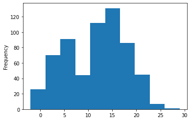

```python
# Turning to feel_temperature, I would like to visualise the distribution first to check for symmetry #

clean_data['feel_temperature'].plot(kind = 'hist')

# We see that it is bidmodal and hence not symmetric around a certain mode like the normal distribution for example
# As such I will impute using the median
```

```python
# Compute the median
temp_median = clean_data['feel_temperature'].median()

# Impute with the median #
clean_data['feel_temperature'] = clean_data['feel_temperature'].fillna(temp_median)

clean_data.info()
```

```
<class 'pandas.core.frame.DataFrame'>
Int64Index: 679 entries, 0 to 729
Data columns (total 10 columns):
 #   Column            Non-Null Count  Dtype
---  ------            --------------  -----
 0   date              679 non-null    datetime64[ns]
 1   real_temperature  679 non-null    float64
 2   feel_temperature  679 non-null    float64
 3   humidity          679 non-null    float64
 4   wind_speed        679 non-null    float64
 5   weather_code      679 non-null    object
 6   is_holiday        679 non-null    bool
 7   is_weekend        679 non-null    bool
 8   season            646 non-null    object
 9   count             679 non-null    int64
dtypes: bool(2), datetime64[ns](1), float64(4), int64(1), object(2)
memory usage: 49.1+ KB
```

```python
# Check the counts for season (check for a mode to impute)

clean_data['season'].value_counts()

# We see that whilst the mode is summer, the overall distribution of categories is quite even. As such I think
# imputing to the mode would create a bias towards the summer category, whereas interpolation relies on more
# unbiased rationale like distance as well as sequential ordering
```

```
summer    176
spring    173
autumm    168
winter    162
Name: season, dtype: int64
```

```python
# Interpolate using pad #

clean_data['season'] = clean_data['season'].interpolate(method = 'pad')

# Check we have no missing values left #

clean_data.isna().sum()
```

```
date                0
real_temperature    0
feel_temperature    0
humidity            0
wind_speed          0
weather_code        0
is_holiday          0
is_weekend          0
season              0
count               0
dtype: int64
```

## 4.5 sklearn alternative

In addition to the missing data filling methods discussed, sklearn includes a range of methods within the impute class. Some basic methods including mean, median, most frequent and constant missing value filling can be implemented using the SimpleImputer class.

## 4.6 Outliers

Outliers in the data - extreme values - may impact our model’s predictive power severely. As a result, these should be found using exploratory techniques such as plotting and using domain knowledge. It may be necessary to remove the outlier data in order to improve model performance.

## 4.7 Summary

In this section we discussed the importance of handling missing data properly, without doing so our model may perform worse, or simply not run. We have a range of options when dealing with missing data, each with tasks they are potentially better suited for.

Dropping missing data can be useful when we don’t want to make assumptions about our data that may skew it, but we need to be careful about the correlation of missing values - i.e. dropping assumes that missing data are random. Replacing the missing values with an average can be a easy to understand approach, with the result being clear, but we must be careful that we do not over use this approach as too much of our data being replaced could cause issues. Finally, there are numerous already designed methods given by pandas, these are preferable to use, but each has a limitation and should be understood before being selected.

In addition to the conventional methods highlighted above, more recent approach and efficient algorithms are based upon imputation of missing values with model based correction. These techniques are called model based methods. Here, the algorithm model the missing data mechanism and then proceed to make a proper likelihood-based analysis either via maximum likelihood or bayesian estimation. This allows the distribution of the data and correlation with other variables to be considered in imputation of the missing data.

# 5 Feature Engineering

So far in this chapter we have been lucky with our data, in that most of it is in a format that both we, and a machine learning algorithm can easily understand. Namely, algorithms thrive on numerical input, but we will not always receive data that is in this format and will often need to convert it into numerical data.

## 5.1 Data Types for Machine Learning

There are a wide array of different data types that can be used in python and programming in general. For machine learning we are going to discuss three general categories.

### 5.1.1 Numerical Data

```python
# Generate some random data of different types.
random_floats = np.random.uniform(low=-50, high=50, size=(15,))
random_ints = np.random.randint(low=-50, high=50, size=(15,))

print("Example floats:\n", random_floats)
print("\nExample integers:\n", random_ints)
```

```
Example floats:
 [-38.45722134 -12.9079834    2.87712286 -32.56063047  17.32032488
  18.70269599  21.08618418 -45.58350919   9.24344729  -1.86825015
 -27.59922697  48.65838577 -19.12427908 -35.93548878 -28.77749875]

Example integers:
 [ 23  20  31 -38 -15 -43 -37 -27  -2   4 -36  39 -26   5  28]
```

This data type is quite self explanatory. It encompasses both float and integer types and is fundamentally anything that is a number at origin. The distance between two numbers has a meaning, the person who is 180cm tall is 10cm taller than the person who is 170cm tall. There is a rigid order to each number, with each data point either being greater than, less than or equal to another.

For ease of calculation many machine learning algorithms will convert integers to floats within their internal processes but this will rarely be noticeable for the user.

An example of the numerical data type in our clean_data set is the real_temperature, feature which represents the temperature measured in degrees celsius.

```python
# Selecting only the numerical data columns in the frame.
numerical_data = clean_data.select_dtypes(include='number')

print(numerical_data.head(n=10),'\n')
print(numerical_data.info())
```

```
   real_temperature  feel_temperature  humidity  wind_speed  count
0              2.75              0.00     93.00    7.500000   9234
1              9.00              7.25     81.50    8.854167  20372
2              8.00              5.75     79.75   16.000000  20613
3              9.00              5.50     81.00   19.760870  21064
4              9.00              6.75     79.50   20.479167  15601
5             13.00             13.00     75.75   32.916667  22104
6             11.50             11.50     66.75   34.312500  14709
7              7.75              3.75     69.00   26.562500  14575
8             11.50             11.50     76.50   28.187500  17199
9              9.00              6.00     74.75   21.208333  24697

<class 'pandas.core.frame.DataFrame'>
Int64Index: 679 entries, 0 to 729
Data columns (total 5 columns):
 #   Column            Non-Null Count  Dtype
---  ------            --------------  -----
 0   real_temperature  679 non-null    float64
 1   feel_temperature  679 non-null    float64
 2   humidity          679 non-null    float64
 3   wind_speed        679 non-null    float64
 4   count             679 non-null    int64
dtypes: float64(4), int64(1)
memory usage: 31.8 KB
None
```

### 5.1.2 Categorical Data (Nominal)

Categorical data is typically a string of characters such as a word or single letter. It is often named nominal data. As data of this type are not numerical, we cannot perform arithmetic between different categorical values, they have no quantitative value. Categorical data has no order to it. These pieces of data are commonly qualitative observations, descriptors, or representations of collections of other data types. Using **pandas/numpy* these are “strings” but often they will be called a generic python data type called “objects”.

```python
# Selecting only the categorical data in the frame.
categorical_data = clean_data.select_dtypes(include="object")

print('The unique categories in "weather_codes" are: \n\n\t {}'.format(categorical_data["weather_code"].unique()))

print('\nThe unique categories in "season" are: \n\n\t {}'.format(categorical_data["season"].unique()))

# Display a random sample of the data to show the variation in values.
categorical_data.sample(n=7)
```

```
The unique categories in "weather_codes" are:

     ['broken_clouds' 'clear' 'scattered_clouds' 'rain' 'cloudy' 'snowfall']

The unique categories in "season" are:

     ['winter' 'spring' 'summer' 'autumm']
```

|  | weather_code | season |
| --- | --- | --- |
| 61 | clear | spring |
| 381 | clear | winter |
| 187 | clear | summer |
| 88 | clear | spring |
| 729 | clear | winter |
| 201 | rain | summer |
| 446 | clear | spring |

We clearly only have two type of explicitly categorical data in this set as shown by the “object” type. However, we can often count boolean values as categorical data (True, False) as they are non-numerical and unordered.

```python
# Selecting only the boolean data from the frame.
boolean_data = clean_data.select_dtypes(include='bool')

boolean_data.head(n=7)
```

|  | is_holiday | is_weekend |
| --- | --- | --- |
| 0 | False | True |
| 1 | False | False |
| 2 | False | False |
| 3 | False | False |
| 4 | False | False |
| 5 | False | False |
| 6 | False | True |

### 5.1.3 Categorical Data (ordinal)

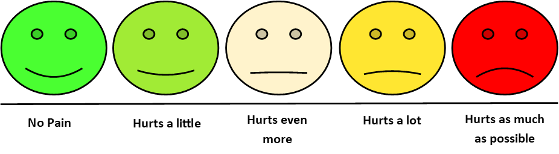

Ordinal data too can be expressed as a string. However, the underlying different possible data values are related to each other in some order. Each data point can be evaluated against each other as: equal to, greater or less than another, but the distance between each data point is not explicitly known. Simply put, there is a natural order to ordinal data.

Examples of ordinal data would include things to do with ranks, such as education level, positions in a running race (first, second, third etc.), satisfaction (very unhappy, unhappy, neutral, happy, very happy).

We have two options when we find that we have ordinal data. We can either treat it as nominal/categorical data and potentially lose the relationship between the two values. Alternatively, ordinal data can be converted to integers, but this may risk our model treating the differences between the values in the data as exact real values.

**Exercise 2:**

Which of the three data types discussed: numerical, ordinal and categorical are the following examples?

- Key Stages in school
- Count of pupils
- Colour of a pupils jumper

```python
# Key Stages in School - Ordinal as they are categorical strings in nature e.g. 'key stage 1', but there is order to them

# Count of Pupils - Numerical as a count is always an integer or a float (usually an integer) #

# Colour of a Pupils Jumoer - Nominal as whilst this contains categorical strings e.g. 'blue', there is no perceived order to them
```

## 5.2 Encoding Data

We have alluded to the fact that our categorical data is not in the format that machine learning algorithms can use. The strings need to be converted into numbers, but how can we do this?

There are two main routes to basic categorical data encoding: label encoding and one-hot encoding. Each of these has a time and a place to be used.

### 5.2.1 Label Encoding

The most obvious method for converting categories to numbers is to do directly just that. The LabelEncoder() class maps each unique category to a different integer.

We can encode the data of categorical variables which maps the new variable as a value from $0$ to $n-1$, where $n$ is the number of unique categories in the feature.

The code below shows how we can implement label encoding with a boolean variable, although it will work for other categorical data with more than two unique types.

```python
# First look at our "is_weekend" data and make a new frame for it.
is_weekend_data = pd.DataFrame(data=clean_data["is_weekend"])
is_weekend_data.head(n=7)
```

|  | is_weekend |
| --- | --- |
| 0 | True |
| 1 | False |
| 2 | False |
| 3 | False |
| 4 | False |
| 5 | False |
| 6 | True |

```python
from sklearn.preprocessing import LabelEncoder

# Create the label encoder object
label_encoder = LabelEncoder()

# Add the fitted and transformed data onto the new frame.
is_weekend_data["encoded_is_weekend"] = label_encoder.fit_transform(y=is_weekend_data["is_weekend"])
is_weekend_data.head(n=7)
```

|  | is_weekend | encoded_is_weekend |
| --- | --- | --- |
| 0 | True | 1 |
| 1 | False | 0 |
| 2 | False | 0 |
| 3 | False | 0 |
| 4 | False | 0 |
| 5 | False | 0 |
| 6 | True | 1 |

Our True values have been converted to $1$ and the False values to $0$. If we had had a third value, that would have taken the value of $2$ and so on up to $n-1$.

Notice how the data input into the LabelEncoder() has an argument of “y=”. This is intentional, the “label” encoder should only be used for the target data variable, in other words the variable we are going to be trying to predict. This is because of the problem we discussed earlier with ordinal data, our model may learn a relationship between the numbers we give it that does not exist because we have given the data in a numerical order.

### 5.2.2 One-Hot Encoding

A different approach to encoding categorical data does not try to replace the character variables with a range of numerical data. Instead one-hot encoding produces a new feature for each category. This means for every unique value within the original feature there is now a new column of data. Sometimes, this is called creating dummy variables.

But what is this new column of data? It is quite a simple idea, each column will contain 1’s and 0’s which will denote whether or not that row has the feature of the new column. This way if we have three different categories, we will then have three different columns. In these columns we will have 1’s and 0’s corresponding to if or if not the original row was the value of that column.

When I said it was simple, I meant it… but it is much easier to visualise than it is to read.

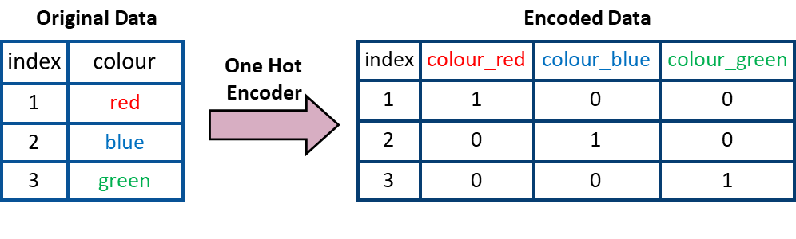

```python
from sklearn.preprocessing import OneHotEncoder

# Fetch the column as a data frame
season_data = pd.DataFrame(data=clean_data["season"])

# Create the encoder object
one_hot_encoder = OneHotEncoder()

# Fit and transform the data to the new encoded form in the same step.
# using the .toarray() method or a sparse output is produced that cannot be passed to pandas
ohe_season_data_array = one_hot_encoder.fit_transform(season_data[["season"]]).toarray()

# Get the names of the new features created.
column_names = one_hot_encoder.get_feature_names_out(['season'])

# Make a data frame with the new data columns.
ohe_season_data = pd.DataFrame(data=ohe_season_data_array, columns=column_names)

# Combine the original season and encoded season data.
ohe_season_data = pd.concat([ohe_season_data, season_data], axis=1)

ohe_season_data.sample(n=10)
```

|  | season_autumm | season_spring | season_summer | season_winter | season |
| --- | --- | --- | --- | --- | --- |
| 467 | 0.0 | 1.0 | 0.0 | 0.0 | NaN |
| 98 | 0.0 | 1.0 | 0.0 | 0.0 | spring |
| 364 | 0.0 | 0.0 | 0.0 | 1.0 | winter |
| 678 | 0.0 | 0.0 | 0.0 | 1.0 | autumm |
| 464 | 0.0 | 1.0 | 0.0 | 0.0 | spring |
| 194 | 0.0 | 0.0 | 1.0 | 0.0 | summer |
| 193 | 0.0 | 0.0 | 1.0 | 0.0 | summer |
| 86 | 0.0 | 1.0 | 0.0 | 0.0 | spring |
| 179 | 0.0 | 0.0 | 1.0 | 0.0 | summer |
| 327 | 0.0 | 0.0 | 0.0 | 1.0 | autumm |

**Warning**

Our results from the one hot encoder are in a **numpy** array, for this reason it is crucial that we reset the indexes on the original data frame or else we will have two different sets of indexes when we combine the separate frames later.

**Exercise 3:**

Using the method shown in this section, one-hot encode the **“weather_code”** feature from **clean_data** and store the new data frame with the new **“weather_code”** columns as **weather_encoded_data**. Include the original **“weather_code”** feature in order to compare the results.

```python
# Write code here

# Get the column as a DataFrame #
weather_code = pd.DataFrame(data = clean_data['weather_code'])

# Create a One-Hot Encoding object #
one_hot_encoder = OneHotEncoder()

# Perform the OHE on the column #
ohe_weather_code = one_hot_encoder.fit_transform(weather_code[['weather_code']]).toarray()

# Column names for the new dataframe we will create #
columns = one_hot_encoder.get_feature_names_out(['weather_code'])

# Create a dataframe for the encoded variable #

weather_code_ohe = pd.DataFrame(data = ohe_weather_code, columns = columns)

weather_code_encoded = pd.concat([weather_code, weather_code_ohe], axis = 1)

weather_code_encoded.info()
```

```
<class 'pandas.core.frame.DataFrame'>
Int64Index: 727 entries, 0 to 729
Data columns (total 7 columns):
 #   Column                         Non-Null Count  Dtype
---  ------                         --------------  -----
 0   weather_code                   679 non-null    object
 1   weather_code_broken_clouds     679 non-null    float64
 2   weather_code_clear             679 non-null    float64
 3   weather_code_cloudy            679 non-null    float64
 4   weather_code_rain              679 non-null    float64
 5   weather_code_scattered_clouds  679 non-null    float64
 6   weather_code_snowfall          679 non-null    float64
dtypes: float64(6), object(1)
memory usage: 45.4+ KB
```

What should we do however if we have incredibly large numbers of categories in our feature? This would generate large numbers of columns which may not be informative for our model to pick out a pattern.

We have a few options in this case, one would be to use dimension reduction, an area of unsupervised machine learning which reduces the number of features in the data set by combining the features mathematically.

Another option would be to aggregate the different categories together. For example, if we have a feature “colours” that contains thousands of different hues such as “turquoise”, “navy”, “aqua” and so on. By mapping each of these different unique categories to broader groups we can reduce the number of different categories. We would categories each of the listed colours under the umbrella of “blue”.

## 5.3 Summary

We will often be given data in a format that our machine learning algorithms cannot easily handle, therefore it is important that we engineer features that can be used from our raw data. The most common types of feature engineering are converting data from one format to another. In this section we have gone into detail about how to convert categorical data to numerical data, using both a label encoder and one hot encoder. There are many more methods for extracting features from data, each type of data will have some natural ways it is converted to a useable feature. However, as always you should check to see what the model you have chosen requires, and also take computational expense into account.

# 6 Data Scaling

## 6.1 What is it, and why do it?

We have now brought our data into the notebook, cleaned it of any missing values and converted it to numerical data. However, we are not yet able to use it to train a model. Notice what the variables in our dataset are: we have temperatures (celsius), wind speeds (km/h) and humidity (% moisture). Our machine learning model will not understand that these different variables are describing very different phenomena.

What matters in most machine learning algorithms is the variations in values for each variable and the correlation between different variables (i.e. the joined distribution of the data space). By scaling variables we can make them into a common form of data that expresses the variation in their values on a level playing field. Real data across different variables will have different sizes, ranges and units. For most machine learning algorithms, we can achieve a better convergence level and can handle/compare the features with different units and scales, if we transform the data into a common form (i.e. keeping the distribution but remove the effect of sizes, ranges and units).

Scaling our data effectively means transforming each different feature to be on the same scale as each other feature.

## 6.2 Standardisation

In order to make our data usable for some algorithms we need to make each variable comparable.

Using what we know about our data can help us to decide which form of scaling is most appropriate. If we assume that the our variables follow a normal distribution then there is a scaler designed to use this information. The scaler reconfigures the values to show the same shape as the data originally shows, but changing the values themselves.

To do this, the scaler uses the mean and standard deviation of the data itself to produce new values called the “standard score” $z_i$, this is given by:

$$z_i = \frac{x_i - \mu}{s}$$

where $x_i$ is a data value, $\mu$ is the mean of the data set and $s$ is the standard deviation of the data samples. This will typically produce a new dataset that now has an average value of $\mu'=0$, and a standard variance of $s'=1$. In other words, we transform the normally distributed variable, $x_i$, to a **standard normal** distribution.

This method is called standard scaling, and is included within the sklearn package sklearn.preprocessing.

Standard Scaling is done **column wise**.

Firstly, lets have a look at one of our variables, real_temperature.

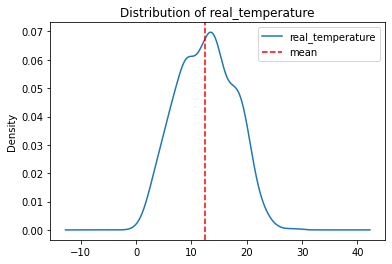

```python
# Creating a figure of the density of a variable across the different values.
ax = clean_data['real_temperature'].plot.density(title="Distribution of real_temperature", label="real_temperature")

mean_real_temperature = clean_data['real_temperature'].mean()

# Plotting the mean value on the distribution against the density.
plt.axvline(x=mean_real_temperature, color='r', linestyle='--', label="mean")
ax.legend();
```

Now this particular variable is not a perfect normal distribution, however, our real world data is rarely going to exactly follow a preprescribed distribution. It does look approximately in the right form so we are going to try to use the standard scaler on it and see what the result looks like.

```python
# Import the specific class we want to use.
from sklearn.preprocessing import StandardScaler

# We need to create the scaler object before we can use it.
standard_scaler = StandardScaler()

# Making a new data frame containing the data we want to process for handling purposes.
real_temperature_data = pd.DataFrame(data=clean_data['real_temperature'])

# We can both fit our scaler to the data and transform the data in one step with fit_transform
clean_data['scaled_real_temperature'] = standard_scaler.fit_transform(X=real_temperature_data)
```

One of the often challenging parts of a machine learning workflow can be the transformation of data into the format that the different functions require. We will go over this, data structures and more later this chapter.

Lets have a look at our newly scaled data to understand what has happened. First by comparing the two columns and then by plotting both.

```python
# We can now compare the pre and post scaled data, using a sample of the data.
clean_data[["real_temperature", "scaled_real_temperature"]].sample(n=10)
```

|  | real_temperature | scaled_real_temperature |
| --- | --- | --- |
| 332 | 13.00 | 0.091430 |
| 320 | 10.00 | -0.500286 |
| 688 | 9.75 | -0.549595 |
| 314 | 10.00 | -0.500286 |
| 556 | 16.00 | 0.683145 |
| 471 | 10.50 | -0.401666 |
| 465 | 14.00 | 0.288668 |
| 329 | 11.75 | -0.155118 |
| 10 | 6.00 | -1.289240 |
| 72 | 8.00 | -0.894763 |

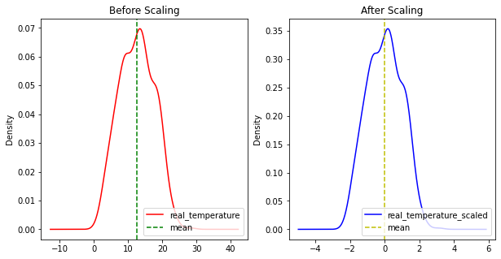

```python
# Generate the plots
fig, (ax1, ax2) = plt.subplots(ncols=2, figsize=(10, 5))

# Plot the pre-scaling distribution.
clean_data['real_temperature'].plot.density(
        ax=ax1, color='r', title="Before Scaling", label="real_temperature")

ax1.axvline(x=mean_real_temperature, color='g', linestyle='--', label="mean")
ax1.legend(loc="lower right")

# Calculate the new mean and plot the post scaling distribution together.
mean_scaled_real_temperature = clean_data['scaled_real_temperature'].mean()

clean_data.scaled_real_temperature.plot.density(
        ax=ax2, color='b', title="After Scaling", label="real_temperature_scaled")

ax2.axvline(x=mean_scaled_real_temperature, color='y', linestyle='--', label="mean")
ax2.legend(loc="lower right");
```

We can now see the effect of standard scaling, the data is maintaining the same distribution shape, but has a mean, $\mu = 0$ and standard deviation, $s \approx 1$.

Let’s drop the scaled_real_temperature column so we have the original cleaned data.

```python
# Remove the scaled data.
clean_data = clean_data.drop(columns=["scaled_real_temperature"])

clean_data.head()
```

|  | date | real_temperature | feel_temperature | humidity | wind_speed | weather_code | is_holiday | is_weekend | season | count |
| --- | --- | --- | --- | --- | --- | --- | --- | --- | --- | --- |
| 0 | 2015-04-01 | 2.75 | 0.00 | 93.00 | 7.500000 | broken_clouds | False | True | winter | 9234 |
| 1 | 2015-05-01 | 9.00 | 7.25 | 81.50 | 8.854167 | broken_clouds | False | False | winter | 20372 |
| 2 | 2015-06-01 | 8.00 | 5.75 | 79.75 | 16.000000 | clear | False | False | winter | 20613 |
| 3 | 2015-07-01 | 9.00 | 5.50 | 81.00 | 19.760870 | scattered_clouds | False | False | winter | 21064 |
| 4 | 2015-08-01 | 9.00 | 6.75 | 79.50 | 20.479167 | rain | False | False | winter | 15601 |

What has happened here may in fact be clearer when you see what happens to multiple features when they are standard scaled at the same time.

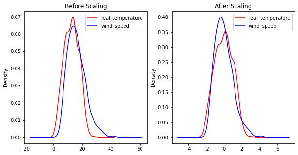

```python
scaled_clean_data = clean_data[["real_temperature", "wind_speed"]]

# Generate the plots
fig, (ax1, ax2) = plt.subplots(ncols=2, figsize=(10, 5))

# Plot the pre-scaling distribution.
clean_data['real_temperature'].plot.density(
        ax=ax1, color='r', title="Before Scaling", label="real_temperature")
clean_data['wind_speed'].plot.density(
        ax=ax1, color='b', title="Before Scaling", label="wind_speed")

scaled_clean_data[["real_temperature", "wind_speed"]] = standard_scaler.fit_transform(X=scaled_clean_data)

scaled_clean_data['real_temperature'].plot.density(
        ax=ax2, color='r', title="After Scaling", label="real_temperature")
scaled_clean_data['wind_speed'].plot.density(
        ax=ax2, color='b', title="After Scaling", label="wind_speed")
ax1.legend()
ax2.legend();
```

We can see that both features, which are two incomparible things (temperature and wind speed) are now on the same scale.

## 6.3 Normalization

If the scale of one feature compared to another is large then we may choose to instead normalize the features. This is particularly crucial for machine learning algorithms that are reliant on distance measurements in the data space (specifically euclidean distance).

Normalization will convert the values of one or more variable into the range of $0 \leq x_i \leq 1$ such that each variable is comparable. The length of each vector will then be equal to 1, a unit length. Where as in scaling we may change the range of the data, in normalization we alter the actual distribution.

This is done by the transformation:
$$q_i = \frac{x_i}{\sqrt{x_i^{2}+y_i^{2}+z_i^{2}}}$$

where $q_i$ is the new value, $x_i$ is the feature in question, $y_i, z_i$ are other features. More generally the normalizer divides each value of $x_i$ by the magnitude of the data point in $n$-dimensional space where $n$ is the number of features.

Normalization is performed **row wise**.

Normalization is fundamentally different to other scaling methods that we will see in this course.

When features are normalized the resulting distribution is altered, not just shifted of stretched. For some machine learning problems this is very useful. For others this may make the resulting features less useful.

Machine learning algorithms/models which use the distance between data points can often benefit from normalization. Families of models that use distance, or “metrics”, include Kernel based models and Nearest Neighbor algorithms.

Supervised models using distance measures:

- k-Nearest Neighbours
- Support Vector Machines (SVMs)

These sorts of models are especially good at modelling non-linear relationships.

Normalization is often a poor choice when the distribution of our feature follows a gaussian distribution of some form. In this case, using one of the scalers discussed is frequently better.

Supervised models where we would rarely use normalisation:

- Linear Regression
- Logistic Regression
- Tree-based models

Lets run through an example of normalizing our data using the humidity and wind_speed features to explore the output.

```python
# Createa smaller data frame to manipulate certain columns.
humidity_wind_data = clean_data[["humidity", "wind_speed"]]

humidity_wind_data.head()
```

|  | humidity | wind_speed |
| --- | --- | --- |
| 0 | 93.00 | 7.500000 |
| 1 | 81.50 | 8.854167 |
| 2 | 79.75 | 16.000000 |
| 3 | 81.00 | 19.760870 |
| 4 | 79.50 | 20.479167 |

```python
from sklearn.preprocessing import Normalizer

# Create normalizer object
normal_scaler = Normalizer()

# Fit and transform the data with the normalizer in a new data frame.
humidity_wind_data_normalized = pd.DataFrame(normal_scaler.fit_transform(X=humidity_wind_data),
                                      columns=["normed_humidity","normed_wind_speed"])

humidity_wind_data_normalized.sample(n=10)
```

|  | normed_humidity | normed_wind_speed |
| --- | --- | --- |
| 287 | 0.981812 | 0.189856 |
| 325 | 0.946935 | 0.321426 |
| 557 | 0.993023 | 0.117921 |
| 141 | 0.887204 | 0.461378 |
| 199 | 0.990195 | 0.139693 |
| 338 | 0.997454 | 0.071312 |
| 384 | 0.993295 | 0.115604 |
| 165 | 0.937764 | 0.347274 |
| 447 | 0.965490 | 0.260442 |
| 633 | 0.963791 | 0.266659 |

But what does this actually look like in our data space?

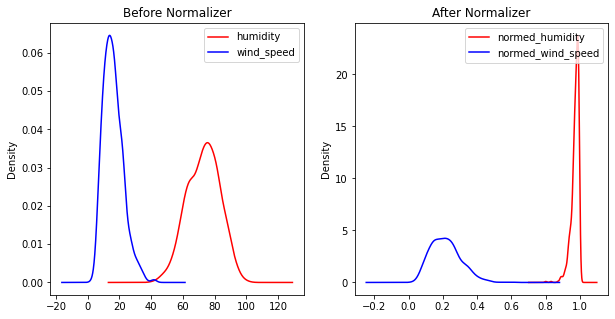

```python
# Generate the plots
fig, (ax1, ax2) = plt.subplots(ncols=2, figsize=(10, 5), sharey=False)

# Plot the pre-normalizing distribution.
humidity_wind_data['humidity'].plot.density(ax=ax1, color='r', title="Before Normalizer")

humidity_wind_data['wind_speed'].plot.density(ax=ax1, color='b')
ax1.legend(loc="upper right")

# Plot the normalized data
humidity_wind_data_normalized['normed_humidity'].plot.density(ax=ax2, color='r', title="After Normalizer")

humidity_wind_data_normalized['normed_wind_speed'].plot.density(ax=ax2, color='b')
ax2.legend(loc="upper right");
```

The two features now have a common range, between 0 and 1. This was achieved by changing the distributions of each features. They are now comparable to each other within the same unit values.

We can somewhat disregard the y-axis in this example. As this is a density the sum of the area underneath each curve must equal 1. As we change the different values of the data, the density changes to keep the sum to 1.

This plot however does not show us what is happening to each row of the data. The below code plots the two features against each other before and after normalisation, showing that the normaliser relates each feature to the other on a row by row basis and creates new values which have a unit length of 1.

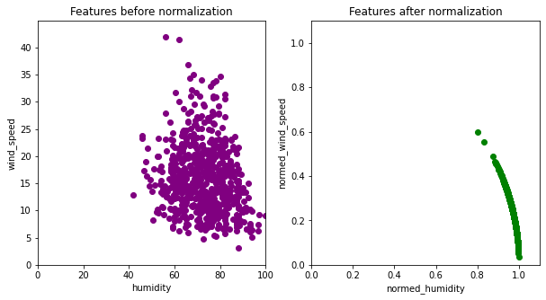

```python
# Generate the plots
fig, (ax1, ax2) = plt.subplots(ncols=2, figsize=(10, 5), sharey=False)

# Plot the pre-normalizing distribution.
ax1.scatter(humidity_wind_data['humidity'], humidity_wind_data['wind_speed'], color='purple')
ax1.set_xlim(0, 100)
ax1.set_ylim(0, humidity_wind_data['wind_speed'].max()+3)
ax1.set_xlabel("humidity")
ax1.set_ylabel("wind_speed")
ax1.set_title("Features before normalization")

# Plot the post-normalizing distribution.
ax2.scatter(humidity_wind_data_normalized['normed_humidity'],
            humidity_wind_data_normalized['normed_wind_speed'],
            color='green')
ax2.set_xlim(0, 1.1)
ax2.set_ylim(0, 1.1)
ax2.set_xlabel("normed_humidity")
ax2.set_ylabel("normed_wind_speed")

ax2.set_title("Features after normalization");
```

## 6.4 Which Scaling Should be Used?

The two examples of scaling above are not exhaustive, there are different methods each appropriate for different data and combinations of features. There are some simple judgments that can be made to pick a method.

- StandardScaler() - When data is normally distributed this is the go to method. Transforms data to have $\mu = 0 , s = 1$.
- Normalizer() - Data is now arranged to be within 1 data distance unit from the centre of the data space. This is useful for algorithms that use euclidean distances to make calculations.
- MinMaxScaler() - This scaler transforms using the minimum and maximum values of the data to within either $0 \leq q \leq 1$ or $-1 \leq q \leq 1$ depending if there are negative data values. This method is especially useful when the input data is not normally distributed. It is able to capture skewness in the data but bring different variables within the same range.
- RobustScaler() - Robust scaling is functionally similar to MinMaxScaling, but instead of using minimum and maximum values, the interquartile range is used instead. This has the effect of being resilient to outlier values which can disrupt the MinMaxScaler.

Not only can data be scaled for standardisation purposes, it can also be converted back from scaled values using the inverse_transform(X=scaled_data) method..

For a more in depth explanation of each method covered, and accompanying graphics, see [Feature Scaling with scikit-learn](http://benalexkeen.com/feature-scaling-with-scikit-learn/)

**Exercise 4:**

For all the *numerical* features in **clean_data** use the *RobustScaler()* to create a new data frame with the scaled data. This scaler has the same syntax as the previous shown. Call this frame **scaled_data**. Be sure to check what your data looks like after it has been scaled.

```python
# Write your code here

# Obtain a dataframe of numeric columns from clean_data #
clean_data_numeric = clean_data.select_dtypes(include = ['int64', 'float64'])

columns = clean_data_numeric.columns

# Import and create the robust scaler object #
from sklearn.preprocessing import RobustScaler

robust_scaler = RobustScaler()

# Fit and transform on the numeric data #
clean_data_robust = pd.DataFrame(robust_scaler.fit_transform(X = clean_data_numeric),
                                 columns = columns)

clean_data_robust
```

|  | real_temperature | feel_temperature | humidity | wind_speed | count |
| --- | --- | --- | --- | --- | --- |
| 0 | -1.355932 | -1.436620 | 1.248 | -0.899672 | -1.562932 |
| 1 | -0.508475 | -0.619718 | 0.512 | -0.741622 | -0.601433 |
| 2 | -0.644068 | -0.788732 | 0.400 | 0.092399 | -0.580628 |
| 3 | -0.508475 | -0.816901 | 0.480 | 0.531346 | -0.541695 |
| 4 | -0.508475 | -0.676056 | 0.384 | 0.615181 | -1.013294 |
| ... | ... | ... | ... | ... | ... |
| 674 | -1.186441 | -1.323944 | 1.696 | -0.724601 | -1.361619 |
| 675 | -0.711864 | -0.873239 | 1.056 | -0.221271 | -1.373878 |
| 676 | -0.779661 | -0.901408 | 1.056 | -0.126440 | -1.805767 |
| 677 | -1.288136 | -1.380282 | 0.576 | -0.471720 | -1.339434 |
| 678 | -1.118644 | -1.380282 | 0.480 | 0.435247 | -0.682234 |

679 rows × 5 columns

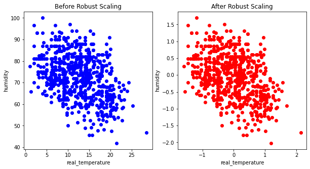

```python
# Visualisation of before and after Robust scaling
fig, (ax1, ax2) = plt.subplots(ncols = 2, figsize = (10, 5))

# Before - Let's observe real temp and humidity #
ax1.scatter(x = clean_data_numeric['real_temperature'], y = clean_data_numeric['humidity'], color = 'blue')
ax1.set_title('Before Robust Scaling')
ax1.set_xlabel('real_temperature')
ax1.set_ylabel('humidity')

# After #
ax2.scatter(x = clean_data_robust['real_temperature'], y = clean_data_robust['humidity'], color = 'red')
ax2.set_title('After Robust Scaling')
ax2.set_xlabel('real_temperature')
ax2.set_ylabel('humidity')
```

## 6.5 Summary

In this section we have seen some methods for scaling our data. We want to scale our data so that different variables are within the same range, and can therefore be compared appropriately by our machine learning algorithms. Without scaling, the differences between features units and ranges could significantly change the sensitivity of our model and its ability to predict. Not all models require scaling, so it is important to both determine if it should be used, and what method is the most appropriate to the data.